# Practical Session 4

## Smoothing and Trends

```r
# Install pacman if not installed already, and activate it
if (!require("pacman")) install.packages("pacman")
# Install, update and activate libraries
pacman::p_load(
  here,
  rio,
  skimr,
  tsibble,
  ISOweek,
  slider,    # for rolling means
  tidyverse
)
```

## Mortality Surveillance data in Spain

The Spanish daily mortality monitoring system is run by the National Centre for Epidemiology in Madrid and gathers data from a stable number of municipalities around the country with a computerised death register; the system is representative of the population of Spain and was developed in 2004 with the objective of identifying exceedances in mortality during the summer period. Data since 2000 were collected retrospectively.

Sessions 4-7 and 11 use data from this mortality surveillance system. Session 10 uses data from the same system, but for only one autonomous community in Spain (Aragón).

## Expected learning outcomes

By the end of the session, participants should be able to:

Describe, test and fit a trend in surveillance data (simple smoothing and regression);

Assess and interpret the significance of trend in surveillance data.

You are provided with a dataset in Stata (`mortality.dta`) which includes variables on week, year, total number of deaths (`cases`) as well as number of deaths among males and females separately.

## Task 4.1

**Assess visually how the total registered number of deaths has been behaving in the years with available data. Save any changes to a new dataset named `mortality_agg`.**

**Discuss your results with your peers.**

**How would you proceed in analysing your data to further understand how mortality behaves?**

## Task 4.1.1 (Optional)

**Would you reach the same conclusions if you were exploring mortality for males and females separately? Discuss with your peers.**

### Moving average and direct statistical modelling of trends

Moving averages are simple methods to visualise the general trend of a series after removing some of the random day-to-day variation by smoothing the data. This allows you to browse your data for periodicity and observe the general trend. In other words, smoothing the data may remove “noise” from your time series and can facilitate visual interpretation.

Moving averages model a time series by calculating the numerical mean of the values adjacent to it. It is calculated for each observation, moving along the time axis: e.g. at each time $t$ and for a window of 5 time units, one way of calculating the moving average is by using the observations at $t-2$, $t-1$, $t$, $t+1$ and $t+2$.

### Regression

Using regression methods against the time variable is a simple and familiar way to look at trends and test the slope with the Wald test provided in the output. The kind of regression and interpretation you will use depends on the nature of your dependent variable – in this case, the number (count) of registered deaths.

## Task 4.2

Assess visually the existence of a long-term trend and periodicity in the `mortality_agg` dataset by using smoothing techniques. Where would you centre the smoothing window and why? What is the effect of using different smoothing window centring options?

## Task 4.3

Assess statistically whether the registered number of deaths has been stable in the years available in your dataset. How well can you model the registered number of deaths by assessing only the long-term trend?

## Task 4.3.1 (Optional)

How could you take the – potentially changing – population of Spain into account in your analyses? Data on population are provided in the file `population.xls`.

## Task 4.3.2 (Optional)

If you are confident with addressing the tasks above and still have enough time, follow the same procedure with the `dis1` dataset. Which regression models (other than linear regression) may be relevant in this example?

## Help for Task 4.1

```r
mortagg <- import(here("data", "mortagg.csv"))
```

Inspect the data.

```r
str(mortagg)
```

```
## 'data.frame':    520 obs. of  5 variables:
##  $ year   : int  2000 2000 2000 2000 2000 2000 2000 2000 2000 2000 ...
##  $ week   : int  1 2 3 4 5 6 7 8 9 10 ...
##  $ cases  : int  6090 6398 6271 6023 5552 5065 4821 4732 4509 4496 ...
##  $ cases_m: int  3196 3291 3263 3130 2860 2719 2555 2507 2384 2407 ...
##  $ cases_f: int  2894 3107 3008 2893 2692 2346 2266 2225 2125 2089 ...
```

```r
summary(mortagg)
```

```
##       year           week           cases         cases_m        cases_f
##  Min.   :2000   Min.   : 1.00   Min.   :3748   Min.   :1988   Min.   :1696
##  1st Qu.:2002   1st Qu.:13.75   1st Qu.:4283   1st Qu.:2273   1st Qu.:1997
##  Median :2004   Median :26.50   Median :4516   Median :2389   Median :2137
##  Mean   :2004   Mean   :26.50   Mean   :4657   Mean   :2458   Mean   :2198
##  3rd Qu.:2007   3rd Qu.:39.25   3rd Qu.:4915   3rd Qu.:2591   3rd Qu.:2328
##  Max.   :2009   Max.   :52.00   Max.   :7343   Max.   :3721   Max.   :3622
```

```r
view(mortagg)
```

```r
skimr::skim(mortagg)
```

Data summary

| Name | mortagg |
| --- | --- |
| Number of rows | 520 |
| Number of columns | 5 |
| _______________________ |  |
| Column type frequency: |  |
| numeric | 5 |
| ________________________ |  |
| Group variables | None |

**Variable type: numeric**

| skim_variable | n_missing | complete_rate | mean | sd | p0 | p25 | p50 | p75 | p100 | hist |
| --- | --- | --- | --- | --- | --- | --- | --- | --- | --- | --- |
| year | 0 | 1 | 2004.50 | 2.88 | 2000 | 2002.00 | 2004.5 | 2007.00 | 2009 | ▇▇▇▇▇ |
| week | 0 | 1 | 26.50 | 15.02 | 1 | 13.75 | 26.5 | 39.25 | 52 | ▇▇▇▇▇ |
| cases | 0 | 1 | 4656.57 | 555.52 | 3748 | 4283.00 | 4516.5 | 4915.00 | 7343 | ▇▇▂▁▁ |
| cases_m | 0 | 1 | 2458.36 | 270.83 | 1988 | 2272.75 | 2389.0 | 2591.25 | 3721 | ▇▇▃▁▁ |
| cases_f | 0 | 1 | 2198.22 | 291.34 | 1696 | 1997.00 | 2137.0 | 2328.00 | 3622 | ▇▇▂▁▁ |

Create a time series object with `tsibble`, using the total case counts and plot it.

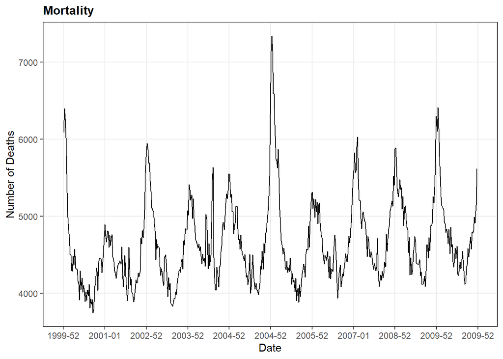

```r
mortz <-
  mortagg %>%
  mutate(date_index = make_yearweek(year = year, week = week)) %>%
  as_tsibble(index = date_index)

# Create tsa_theme from previous exercise
tsa_theme <- theme_bw() +
        theme(
            plot.title = element_text(face = "bold",
                                      size = 12),
            legend.background = element_rect(fill = "white",
                                             size = 4,
                                             colour = "white"),
            # legend.justification = c(0, 1),
            legend.position = "bottom",
            panel.grid.minor = element_blank()
        )
ggplot(data = mortz) +
  geom_line(mapping = aes(x = date_index, y = cases)) +
  scale_x_yearweek(date_labels = "%Y-%W", date_breaks = "1 year") +
  labs(x = "Date", y = "Number of Deaths", title = "Mortality") +
  tsa_theme
```

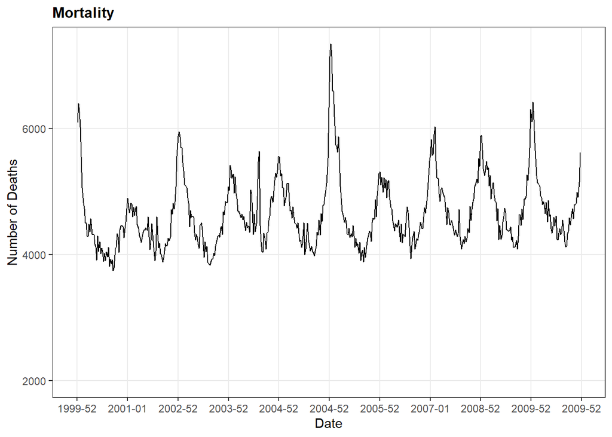

```r
## Adjusting y-axis scale
ggplot(data = mortz) +
  geom_line(mapping = aes(x = date_index, y = cases)) +
  scale_x_yearweek(date_labels = "%Y-%W", date_breaks = "1 year") +
  scale_y_continuous(limits = c(2000, NA)) +
  labs(x = "Date", y = "Number of Deaths", title = "Mortality") +
  tsa_theme
```

## Help for Task 4.1.1

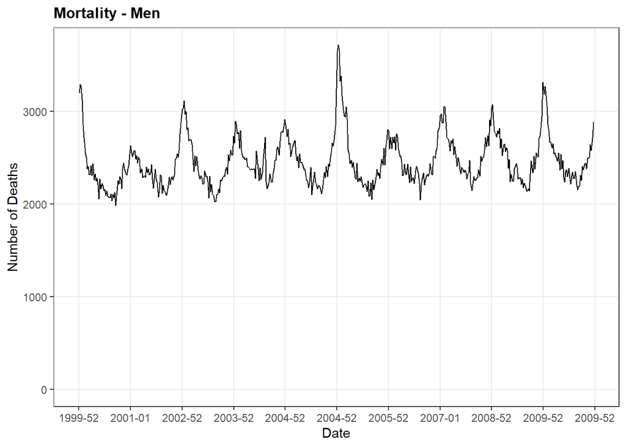

```r
## Men
ggplot(data = mortz) +
  geom_line(mapping = aes(x = date_index, y = cases_m)) +
  scale_x_yearweek(date_labels = "%Y-%W", date_breaks = "1 year") +
  scale_y_continuous(limits = c(0, NA)) +
  labs(x = "Date", y = "Number of Deaths", title = "Mortality - Men") +
  tsa_theme
```

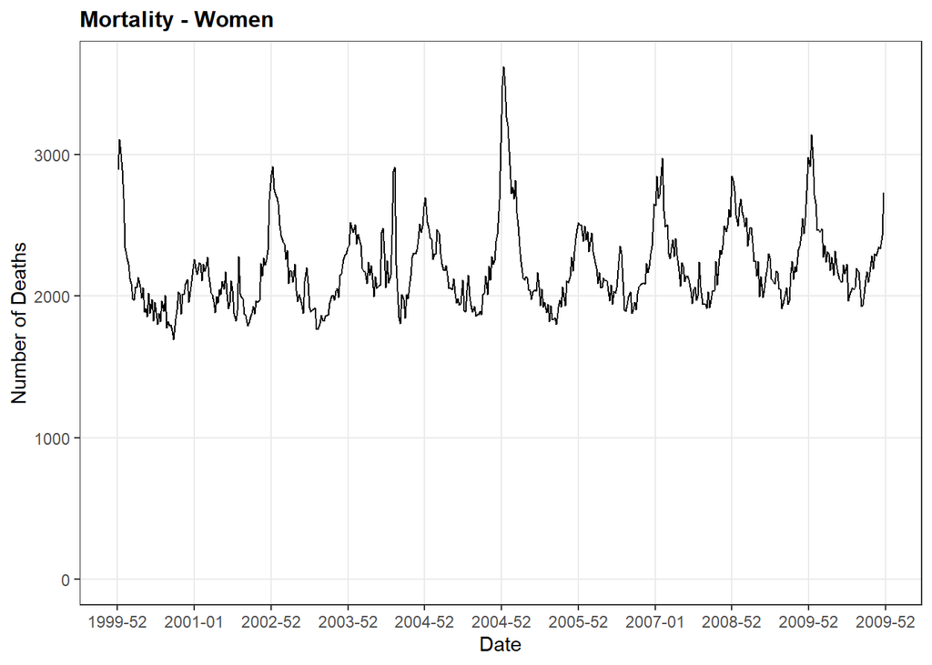

```r
## Women
ggplot(data = mortz) +
  geom_line(mapping = aes(x = date_index, y = cases_f)) +
  scale_x_yearweek(date_labels = "%Y-%W", date_breaks = "1 year") +
  scale_y_continuous(limits = c(0, NA)) +
  labs(x = "Date", y = "Number of Deaths", title = "Mortality - Women") +
  tsa_theme
```

## Help for Task 4.2

According to the `slider` package description, `slider` is a package for rolling windows analysis. It means that a given function is repeatedly applied to different “windows” of your data as you step through it. Typical examples of applications of rolling window window functions include moving averages or cumulative sums.

The `slider` family of functions from the `slider` package contains a collection of functions specifically designed to compute a given operation on a rolling window. An introduction vignette for slider can be found by running the following command: `vignette("slider")`

For each record, create the following various types of moving average.

- `MA5a`: the 5-week moving average, centred on cases.
- `MA5b`: the 5-week moving average of cases and the 4 previous weeks.
- `MA5c`: the 5-week moving average of the 5 previous weeks.

Compare results.

```r
mortzma <-
  mortz %>%
  mutate(
    MA5a = slide_index_dbl(
      .x = cases,
      .i = date_index,
      .f = mean,
      na.rm = TRUE,
      .before = 2,
      .after = 2,
      .complete = TRUE
    ),
    MA5b = slide_index_dbl(
      .x = cases,
      .i = date_index,
      .f = mean,
      na.rm = TRUE,
      .before = 4,
      .complete = TRUE
    ),
    MA5c = slide_index_dbl(
      .x = cases,
      .i = date_index,
      .f = function(x) mean(x[-6], na.rm = TRUE),
      .before = 5,
      .complete = TRUE
    )
  )

# view first 10 lines of data
head(mortzma, 10)
```

```
## # A tsibble: 10 x 9 [1W]
##     year  week cases cases_m cases_f date_index  MA5a  MA5b  MA5c
##    <int> <int> <int>   <int>   <int>     <week> <dbl> <dbl> <dbl>
##  1  2000     1  6090    3196    2894   2000 W01   NA    NA    NA
##  2  2000     2  6398    3291    3107   2000 W02   NA    NA    NA
##  3  2000     3  6271    3263    3008   2000 W03 6067.   NA    NA
##  4  2000     4  6023    3130    2893   2000 W04 5862.   NA    NA
##  5  2000     5  5552    2860    2692   2000 W05 5546. 6067.   NA
##  6  2000     6  5065    2719    2346   2000 W06 5239. 5862. 6067.
##  7  2000     7  4821    2555    2266   2000 W07 4936. 5546. 5862.
##  8  2000     8  4732    2507    2225   2000 W08 4725. 5239. 5546.
##  9  2000     9  4509    2384    2125   2000 W09 4571  4936. 5239.
## 10  2000    10  4496    2407    2089   2000 W10 4465  4725. 4936.
```

The `slide_index_dbl` is a `slider` package function designed to run a pre-specified function on a rolling window of a numeric (`_dbl`) variable, ordered by an index time (date or date-time) variable. A full description of this function can be found by running the following command: `?slide_index_dbl`

The `.x` argument provides the vector with the numbers that will be used for computation.

The `.i` argument defines the vector with the time variable that will be used for ordering the data.

The `.f` argument indicates the function that will be used to perform the intended computations. In this case, an arithmetic mean computation is carried out by using the `mean` function. The `na.rm = TRUE` is a varying argument included as a `...` argument of `slide_index_dbl`. (Run the expression `args("slide_index_dbl")` and take notice on the position/sequence of this function’s arguments).

The `.before` argument defines the number of observations before the central time point of a given time window to use in the rolling window computation. In the example above for a 5 time points centred moving average, in `MA5a`, 2 observations are used before the central point, and 2 observations are used after it, using the `.after` argument.

The `complete` argument indicates where the computation should be carried in rolling windows that have complete observations.

We applied a more complicated function to compute `MA5c`, taking a backwards moving window of six values but omitting the latest value (current time point) from the calculation of the average.

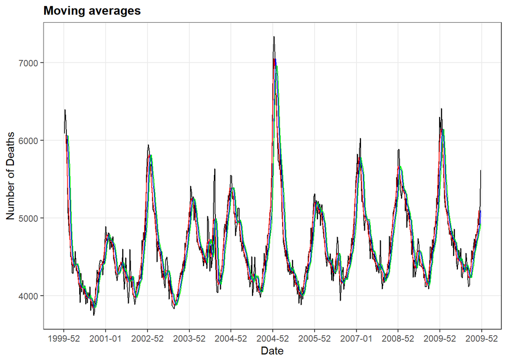

```r
## wide format dataset ---
ggplot(data = mortzma, mapping = aes(x = date_index)) +
  geom_line(mapping = aes(y = cases), colour = "black") +
  geom_line(mapping = aes(y = MA5a), colour = "red") +
  geom_line(mapping = aes(y = MA5b), colour = "blue") +
  geom_line(mapping = aes(y = MA5c), colour = "green") +
  scale_x_yearweek(date_labels = "%Y-%W",
                   date_breaks = "1 year") +
  labs(x = "Date",
       y = "Number of Deaths",
       title = "Moving averages") +
  tsa_theme
```

We observe that the calculation is similar across these various methods, but is not aligned to the series in the same way. `MA5a` is centred in the middle of the period used to calculate the mean. `MA5b` is placed at the end of the period. `MA5c` is placed one step forward (smoothing functions can be used for forecasting the following point). The “models” provided are similar for a 5-week window, but the *lag* is different.